# 1. Set-up y carga de datos

Se realiza la configuración inicial del entorno de trabajo y se carga el conjunto de datos a analizar. A continuación, se describe el proceso:

- El archivo `milknew.csv` es cargado en R mediante la función `read.csv()`. Este archivo contiene los datos que serán utilizados para el análisis.
- Se verifica la dimensión del conjunto de datos utilizando la función `dim()` para confirmar el número de filas y columnas.
- Finalmente, se cargan las bibliotecas necesarias para el análisis exploratorio y visualización de datos: `tidyverse`, `skimr`, `ggplot2` y `corrplot`.

Cabe destacar que hay que instalar los paquetes con `install.packages(pkgs)` si no están previamente descargados en el dispositivo a usar.

```r
milknew <- read.csv("milknew.csv")
dim(milknew)
```

```
## [1] 1059    8
```

```r
library(tidyverse)
library(skimr)
```

```r
library(ggplot2)
library(corrplot)
library(patchwork)
library(caret)
library(nnet)
library(rpart)
library(rpart.plot)
library(ggplot2)
library(randomForest)
library(class)
```

# 2. Preprocesamiento de datos

A continuación, se realiza el preprocesamiento de los datos para prepararlos adecuadamente antes del análisis. Los pasos incluyen:

- Se utiliza la función `head()` para visualizar las primeras filas del conjunto de datos y obtener una idea general de su estructura.
- Se verifica la presencia de valores faltantes en cada columna utilizando `colSums(is.na(milknew))`. En este caso, no se detectan valores faltantes, por lo que no es necesario implementar técnicas de imputación.
- Se elimina la columna `Colour` del conjunto de datos, ya que no será utilizada en el análisis. Esto se realiza mediante la función `select()` del paquete `dplyr`.
- La variable `Grade`, originalmente categórica con niveles “low”, “medium” y “high”, se transforma en una variable numérica ordinal. Esto se logra convirtiendo los niveles en factores ordenados y posteriormente en valores numéricos (0, 1, 2).

```r
head(milknew)
```

```
##    pH Temprature Taste Odor Fat Turbidity Colour  Grade
## 1 6.6         35     1    0   1         0    254   high
## 2 6.6         36     0    1   0         1    253   high
## 3 8.5         70     1    1   1         1    246    low
## 4 9.5         34     1    1   0         1    255    low
## 5 6.6         37     0    0   0         0    255 medium
## 6 6.6         37     1    1   1         1    255   high
```

```r
colSums(is.na(milknew))
```

```
##         pH Temprature      Taste       Odor        Fat  Turbidity     Colour
##          0          0          0          0          0          0          0
##      Grade
##          0
```

```r
data_clean <- milknew %>%
  select(-Colour)
data_clean$Grade <- as.integer(factor(data_clean$Grade, levels = c("low", "medium", "high"), ordered = TRUE)) - 1
data_clean$Grade <- as.integer(data_clean$Grade)

head(data_clean)
```

```
##    pH Temprature Taste Odor Fat Turbidity Grade
## 1 6.6         35     1    0   1         0     2
## 2 6.6         36     0    1   0         1     2
## 3 8.5         70     1    1   1         1     0
## 4 9.5         34     1    1   0         1     0
## 5 6.6         37     0    0   0         0     1
## 6 6.6         37     1    1   1         1     2
```

# 3. Exploración de Datos

En esta sección, realizamos un análisis exploratorio de los datos para comprender mejor las relaciones entre las variables y su distribución. A continuación, se describen los pasos realizados:

## 3.1 Resumen Estadístico

Generamos un resumen estadístico de las variables numéricas utilizando la función `summary()`. Esto proporciona información sobre la media, mediana, mínimo, máximo y otros estadísticos descriptivos.

```r
# Resumen estadístico de variables numéricas
summary(data_clean)
```

```
##        pH         Temprature        Taste             Odor
##  Min.   :3.00   Min.   :34.00   Min.   :0.0000   Min.   :0.0000
##  1st Qu.:6.50   1st Qu.:38.00   1st Qu.:0.0000   1st Qu.:0.0000
##  Median :6.70   Median :41.00   Median :1.0000   Median :0.0000
##  Mean   :6.63   Mean   :44.23   Mean   :0.5467   Mean   :0.4325
##  3rd Qu.:6.80   3rd Qu.:45.00   3rd Qu.:1.0000   3rd Qu.:1.0000
##  Max.   :9.50   Max.   :90.00   Max.   :1.0000   Max.   :1.0000
##       Fat           Turbidity         Grade
##  Min.   :0.0000   Min.   :0.000   Min.   :0.0000
##  1st Qu.:0.0000   1st Qu.:0.000   1st Qu.:0.0000
##  Median :1.0000   Median :0.000   Median :1.0000
##  Mean   :0.6714   Mean   :0.491   Mean   :0.8366
##  3rd Qu.:1.0000   3rd Qu.:1.000   3rd Qu.:1.0000
##  Max.   :1.0000   Max.   :1.000   Max.   :2.0000
```

## 3.2 Distribución de `Grade`

El gráfico de barras muestra la frecuencia de cada categoría de `Grade`.

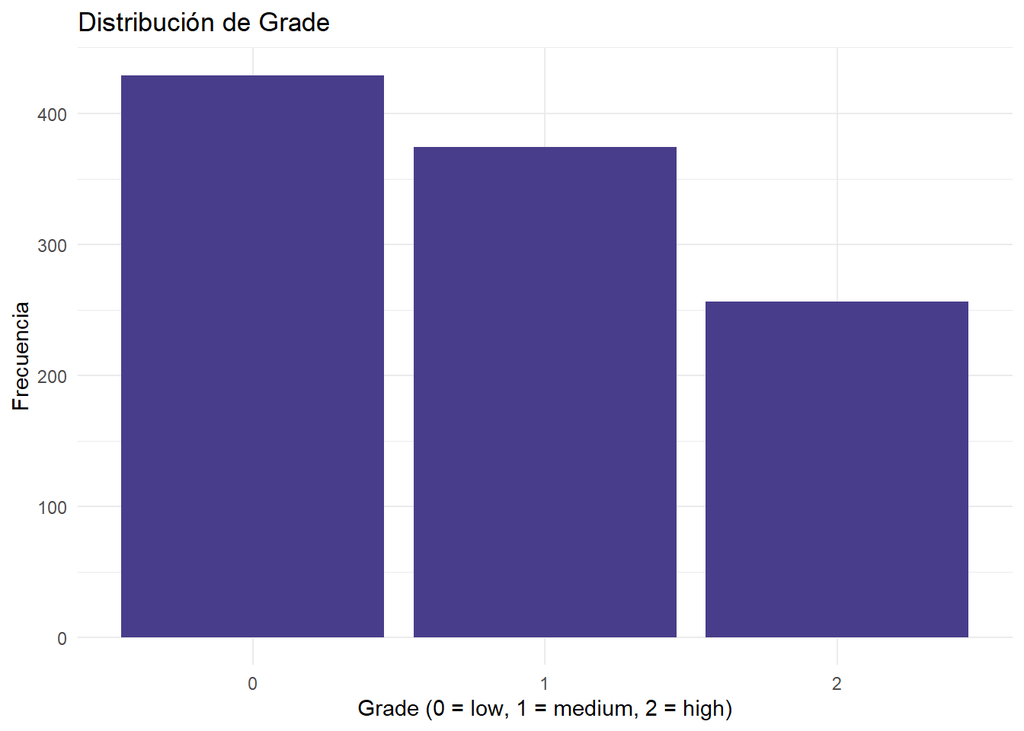

```r
ggplot(data_clean, aes(x = as.factor(Grade))) +
  geom_bar(fill = "darkslateblue") +
  labs(title = "Distribución de Grade",
       x = "Grade (0 = low, 1 = medium, 2 = high)",
       y = "Frecuencia") +
  theme_minimal()
```

## 3.3 Correlaciones entre Variables Numéricas

Para comprender mejor las relaciones lineales entre las variables numéricas del dataset, calculamos y visualizamos la matriz de correlaciones. Esto nos permite identificar qué variables están más relacionadas entre sí y cómo se relacionan con `Grade`.

La matriz de correlaciones muestra los coeficientes de correlación de Pearson entre cada par de variables. Un valor cercano a 1 indica una fuerte correlación positiva, mientras que un valor cercano a -1 indica una fuerte correlación negativa. Los valores cercanos a 0 indican poca o ninguna relación lineal. El plotde estos datos se desglosa en el apartado “3.8 Heatmap de Correlaciones”

```r
cor_matrix <- cor(data_clean %>% select(where(is.numeric)))
round(cor_matrix, 2)
```

```
##               pH Temprature Taste  Odor   Fat Turbidity Grade
## pH          1.00       0.24 -0.06 -0.08 -0.09      0.05  0.03
## Temprature  0.24       1.00 -0.11 -0.05  0.02      0.19 -0.42
## Taste      -0.06      -0.11  1.00  0.02  0.32      0.06  0.03
## Odor       -0.08      -0.05  0.02  1.00  0.31      0.46  0.15
## Fat        -0.09       0.02  0.32  0.31  1.00      0.33  0.15
## Turbidity   0.05       0.19  0.06  0.46  0.33      1.00 -0.15
## Grade       0.03      -0.42  0.03  0.15  0.15     -0.15  1.00
```

## 3.4 Distribución de Variables Numéricas por `Grade`

Los histogramas muestran la distribución de cada variable numérica (`pH`, `Temprature`, `Taste`, etc.) segmentada por los niveles de `Grade`.

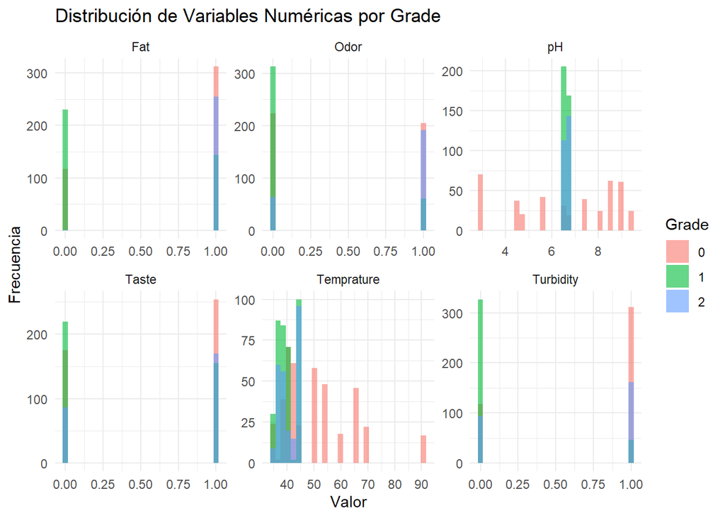

```r
data_clean %>%
  pivot_longer(cols = c(pH, Temprature, Taste, Odor, Fat, Turbidity),
               names_to = "Variable", values_to = "Valor") %>%
  ggplot(aes(x = Valor, fill = as.factor(Grade))) +
  geom_histogram(alpha = 0.6, position = "identity", bins = 30) +
  facet_wrap(~ Variable, scales = "free") +
  labs(title = "Distribución de Variables Numéricas por Grade",
       x = "Valor", y = "Frecuencia", fill = "Grade") +
  theme_minimal()
```

## 3.5 Boxplots de Variables Numéricas por `Grade`

Para analizar cómo se distribuyen las variables numéricas según los niveles de `Grade` (0 = low, 1 = medium, 2 = high), utilizamos gráficos de caja (**boxplots**). Estos gráficos nos permiten identificar diferencias en la mediana, la dispersión y la presencia de valores atípicos entre las categorías de calidad del producto lácteo.

Los boxplots muestran la distribución de cada variable numérica (`pH`, `Temprature`, `Taste`, etc.) segmentada por los niveles de `Grade`. Esto nos ayuda a detectar patrones o anomalías en los datos.

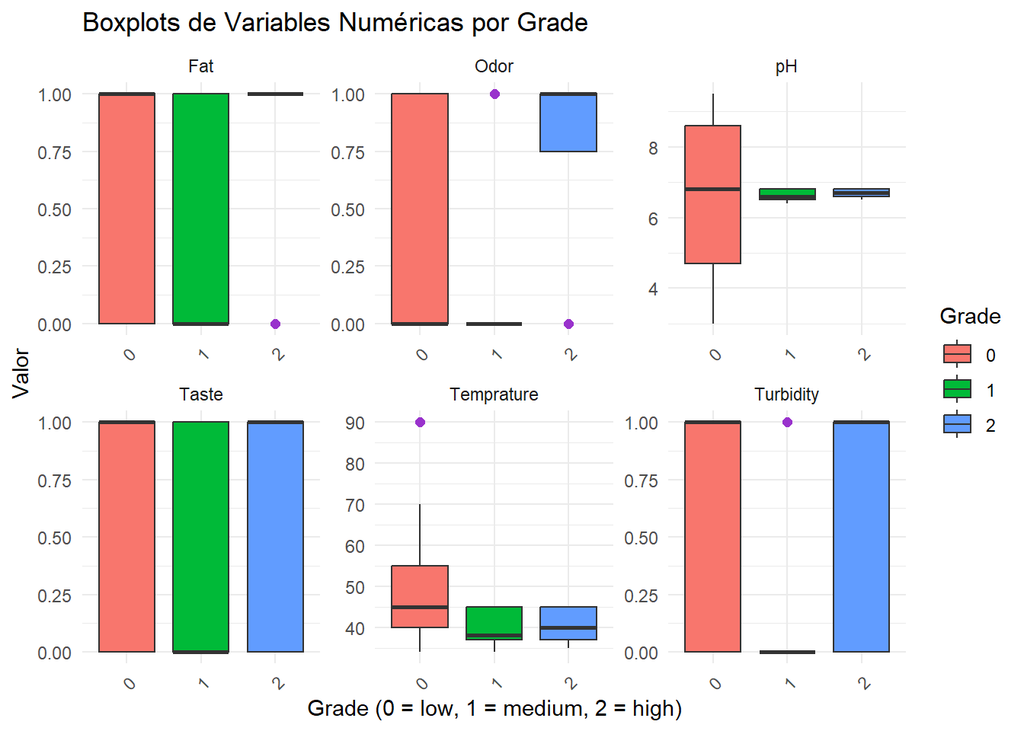

```r
data_clean %>%
  pivot_longer(
    cols = -Grade,
    names_to = "Variable",
    values_to = "Valor"
  ) %>%
  ggplot(aes(x = as.factor(Grade), y = Valor, fill = as.factor(Grade))) +
  geom_boxplot(outlier.color = "darkorchid", outlier.size = 2) +
  facet_wrap(~ Variable, scales = "free") +
  labs(
    title = "Boxplots de Variables Numéricas por Grade",
    x = "Grade (0 = low, 1 = medium, 2 = high)",
    y = "Valor",
    fill = "Grade"
  ) +
  theme_minimal() +
  theme(axis.text.x = element_text(angle = 45, hjust = 1))
```

## 3.6 Relaciones entre Variables Numéricas

Para explorar las relaciones entre pares de variables numéricas, se utilizan gráficos de dispersión (**scatterplots**). Estos gráficos permiten visualizar cómo se relacionan dos variables continuas entre sí y, además, se colorean los puntos según los niveles de `Grade` (0 = low, 1 = medium, 2 = high). Esto nos ayuda a identificar patrones o tendencias que puedan existir entre las variables en función de la calidad del producto lácteo.

En este caso, se analiza la relación entre `pH` y `Temperatura`, dos variables clave en el análisis de la calidad de la leche. El gráfico permite observar si existe una asociación clara entre estas variables y cómo esta relación varía en función de los niveles de calidad (`Grade`).

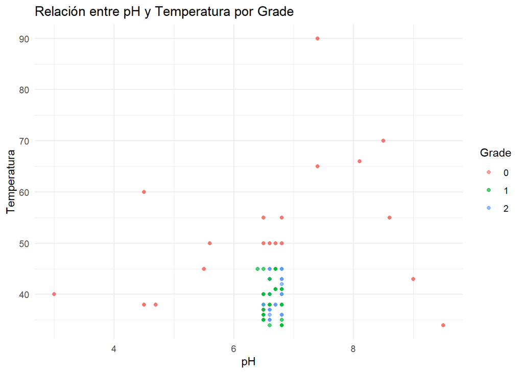

```r
ggplot(data_clean, aes(x = pH, y = Temprature, color = as.factor(Grade))) +
  geom_point(alpha = 0.7) +
  labs(title = "Relación entre pH y Temperatura por Grade",
       x = "pH", y = "Temperatura", color = "Grade") +
  theme_minimal()
```

## 3.7 Análisis de Variables Binarias

Las variables binarias (`Taste`, `Odor`, `Fat`, `Turbidity`) son características categóricas que pueden tomar valores de 0 o 1. Para analizar su relación con la variable objetivo `Grade`, se utilizan gráficos de barras apiladas. Estos gráficos muestran la proporción de cada nivel de `Grade` dentro de cada categoría de las variables binarias.

Este análisis permite identificar si ciertas características binarias están asociadas con niveles específicos de calidad. Por ejemplo, puede revelar si un valor de `Taste = 1` está más frecuentemente relacionado con productos de alta calidad (`Grade = 2`) o viceversa.

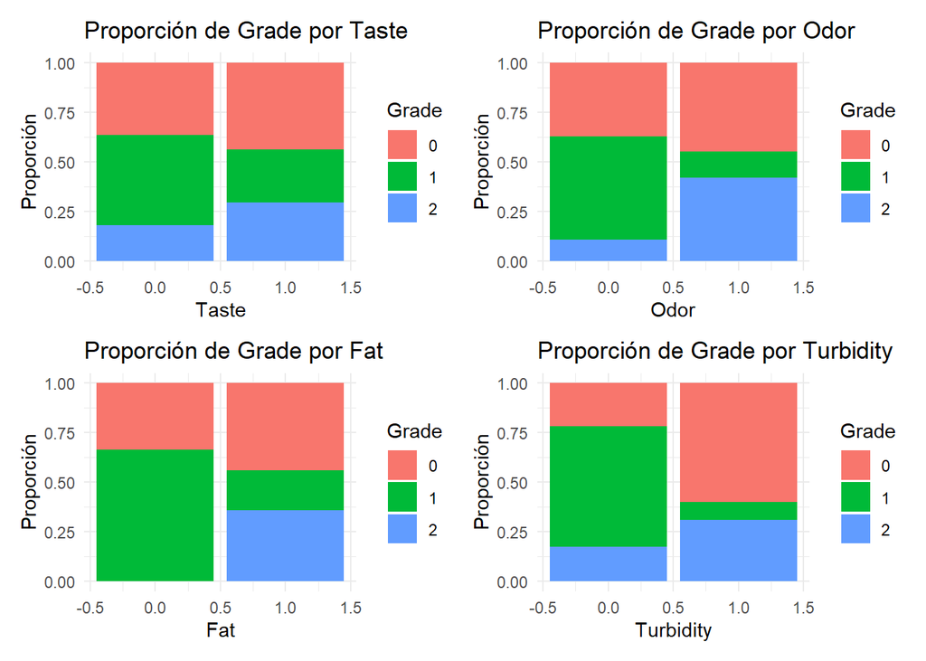

```r
binary_vars <- c("Taste", "Odor", "Fat", "Turbidity")

binary_plots <- lapply(binary_vars, function(var) {
  ggplot(data_clean, aes_string(x = var, fill = "as.factor(Grade)")) +
    geom_bar(position = "fill") +
    labs(title = paste("Proporción de Grade por", var),
         x = var, y = "Proporción", fill = "Grade") +
    theme_minimal()
})
wrap_plots(binary_plots, ncol = 2)
```

## 3.8 Heatmap de Correlaciones

Para visualizar de manera más intuitiva las correlaciones entre las variables numéricas, se genera un **heatmap**. Este gráfico utiliza una escala de colores para representar la intensidad de las correlaciones, donde tonos más oscuros indican correlaciones más fuertes (positivas o negativas), y tonos más claros indican correlaciones débiles o inexistentes.

El heatmap proporciona una visión general de las relaciones lineales entre todas las variables numéricas del dataset, incluyendo su relación con `Grade`. Esto es especialmente útil para identificar variables altamente correlacionadas que podrían ser redundantes o para detectar variables que tienen una fuerte influencia en la calidad del producto lácteo.

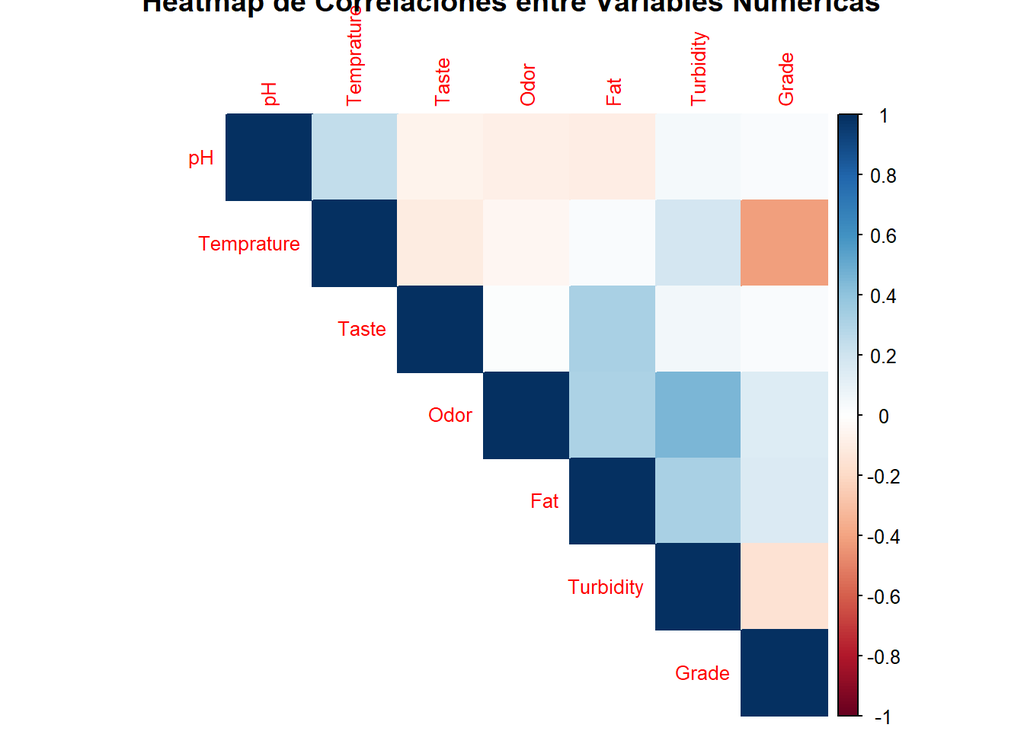

```r
cor_matrix <- cor(data_clean %>% select(where(is.numeric)))
library(corrplot)
corrplot(cor_matrix, method = "color", type = "upper", tl.cex = 0.8,
         title = "Heatmap de Correlaciones entre Variables Numéricas")
```

# 4. Modelado

En esta sección, desarrollaremos modelos de clasificación supervisada para predecir la variable `Grade` (0 = low, 1 = medium, 2 = high) utilizando las características numéricas y binarias del conjunto de datos. Los pasos incluyen:

## 4.1 División del Conjunto de Datos

Primero, dividimos los datos en conjuntos de entrenamiento y prueba para evaluar el rendimiento de los modelos. Utilizamos una proporción común de 80% para entrenamiento y 20% para prueba.

```r
set.seed(123) # Para estratificar

trainIndex <- createDataPartition(data_clean$Grade, p = 0.8, list = FALSE)
train_data <- data_clean[trainIndex, ]
test_data <- data_clean[-trainIndex, ]

dim(train_data)
```

```
## [1] 848   7
```

## 4.2 Escalado de Variables Numéricas

Para mejorar el rendimiento de algunos modelos (como SVM o KNN), escalamos las variables numéricas. Esto asegura que todas las variables tengan la misma escala.

```r
preProcValues <- preProcess(train_data %>% select(where(is.numeric)), method = c("center", "scale"))
train_data_scaled <- predict(preProcValues, train_data %>% select(where(is.numeric)))
test_data_scaled <- predict(preProcValues, test_data %>% select(where(is.numeric)))

train_data_scaled <- cbind(train_data_scaled, Grade = train_data$Grade)
test_data_scaled <- cbind(test_data_scaled, Grade = test_data$Grade)
```

## 4.3 Entrenamiento de Modelos

Entrenaremos varios modelos de clasificación para comparar su rendimiento. Los modelos seleccionados son:

- Regresión Logística
- Árbol de Decisión
- Random Forest
- K-Nearest Neighbors (KNN)

### 4.3.1 Regresión Logística Multinomial

La regresión logística multinomial es una extensión de la regresión logística que permite manejar más de dos clases y puesto que el output de nuestro modelo es ordinal y no binomial, necesitamos emplear este en contraparte a la regresión logística simple. Utilizaremos el paquete nnet para entrenar este modelo.

```r
multinom_model <- multinom(Grade ~ ., data = train_data_scaled)
summary(multinom_model)
```

```
## Call:
## multinom(formula = Grade ~ ., data = train_data_scaled)
##
## Coefficients:
##                   (Intercept)        pH Temprature      Taste       Odor
## 0.210683691412651  -0.8692236 0.7727237  -2.495446 -1.2325811 -0.2211212
## 1.47777426104334   -2.7584675 0.9336030  -3.435450 -0.6107926  1.0861248
##                          Fat  Turbidity
## 0.210683691412651 -0.3599912 -1.9656035
## 1.47777426104334   3.2963061 -0.7659702
##
## Std. Errors:
##                   (Intercept)        pH Temprature     Taste      Odor
## 0.210683691412651   0.1708971 0.1412257  0.2117180 0.1614970 0.1453737
## 1.47777426104334    0.4286378 0.1275434  0.3238405 0.1474943 0.1606891
##                         Fat Turbidity
## 0.210683691412651 0.1297622 0.1812323
## 1.47777426104334  0.5372332 0.1510725
##
## Residual Deviance: 915.4876
## AIC: 943.4876
```

### 4.3.2 Árbol de decisión

El árbol de decisión es un modelo no paramétrico que divide los datos en función de umbrales de las variables predictoras.

Los valores -1.05, 0.21 y 1.47 son los valores de `Grade` (0, 1 y 2 respectivamente) normalizados.

```r
tree_model <- rpart(Grade ~ .,
                   data = train_data_scaled,
                   method = "class",
                   control = rpart.control(minsplit = 20,
                                         cp = 0.01,
                                         maxdepth = 4))
```

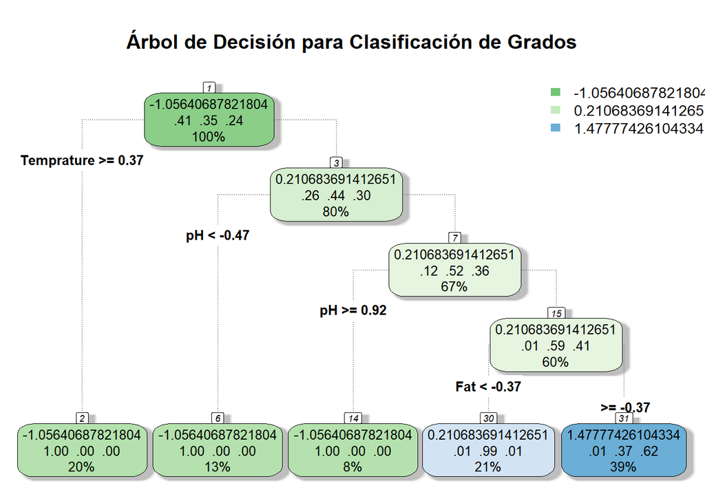

```r
par(mar = c(5, 4, 4, 2) + 0.1)
par(xpd = TRUE)

rpart.plot(tree_model,
          type = 4,
          extra = 104,
          box.palette = "GnBu",
          branch.lty = 3,
          shadow.col = "gray",
          nn = TRUE,
          cex = 0.8,
          fallen.leaves = TRUE,
          main = "Árbol de Decisión para Clasificación de Grados")
```

### 4.3.3 Random Forest

Random Forest es un modelo basado en ensambles que combina múltiples árboles de decisión para mejorar la precisión y reducir el sobreajuste.

Los valores -1.05, 0.21 y 1.47 son los valores de `Grade` (0, 1 y 2 respectivamente) normalizados.

```r
rf_model <- randomForest(as.factor(Grade) ~ ., data = train_data_scaled, ntree = 100, importance = TRUE)
print(rf_model)
```

```
##
## Call:
##  randomForest(formula = as.factor(Grade) ~ ., data = train_data_scaled,      ntree = 100, importance = TRUE)
##                Type of random forest: classification
##                      Number of trees: 100
## No. of variables tried at each split: 2
##
##         OOB estimate of  error rate: 0.12%
## Confusion matrix:
##                   -1.05640687821804 0.210683691412651 1.47777426104334
## -1.05640687821804               346                 0                0
## 0.210683691412651                 0               297                0
## 1.47777426104334                  0                 1              204
##                   class.error
## -1.05640687821804 0.000000000
## 0.210683691412651 0.000000000
## 1.47777426104334  0.004878049
```

### 4.3.4 K-Nearest Neighbors (KNN)

KNN es un modelo basado en instancias que clasifica un punto en función de sus vecinos más cercanos.

```r
knn_model <- knn(train = train_data_scaled %>% select(-Grade),
                 test = test_data_scaled %>% select(-Grade),
                 cl = train_data_scaled$Grade,
                 k = 5)
# Crear un vector de etiquetas reales
true_labels <- as.factor(test_data_scaled$Grade)

# Convertir las predicciones a factores para asegurar consistencia
predictions_knn <- factor(knn_model, levels = levels(true_labels))

# Calcular la matriz de confusión
conf_matrix_knn <- confusionMatrix(predictions_knn, true_labels)

# Mostrar la matriz de confusión y métricas de evaluación
print(conf_matrix_knn)
```

```
## Confusion Matrix and Statistics
##
##                    Reference
## Prediction          -1.05640687821804 0.210683691412651 1.47777426104334
##   -1.05640687821804                82                 0                0
##   0.210683691412651                 1                77                3
##   1.47777426104334                  0                 0               48
##
## Overall Statistics
##
##                Accuracy : 0.981
##                  95% CI : (0.9522, 0.9948)
##     No Information Rate : 0.3934
##     P-Value [Acc > NIR] : < 2.2e-16
##
##                   Kappa : 0.9709
##
##  Mcnemar's Test P-Value : NA
##
## Statistics by Class:
##
##                      Class: -1.05640687821804 Class: 0.210683691412651
## Sensitivity                            0.9880                   1.0000
## Specificity                            1.0000                   0.9701
## Pos Pred Value                         1.0000                   0.9506
## Neg Pred Value                         0.9922                   1.0000
## Prevalence                             0.3934                   0.3649
## Detection Rate                         0.3886                   0.3649
## Detection Prevalence                   0.3886                   0.3839
## Balanced Accuracy                      0.9940                   0.9851
##                      Class: 1.47777426104334
## Sensitivity                           0.9412
## Specificity                           1.0000
## Pos Pred Value                        1.0000
## Neg Pred Value                        0.9816
## Prevalence                            0.2417
## Detection Rate                        0.2275
## Detection Prevalence                  0.2275
## Balanced Accuracy                     0.9706
```